# Project4 Group10

### Step 1 Load Data and Train-test Split

```r
library(dplyr)
```

```r
library(tidyr)
library(ggplot2)
library(purrr)
data <- read.csv("../data/ml-latest-small/ratings.csv")
set.seed(0)
test_idx <- sample(1:nrow(data), round(nrow(data)/5, 0))
train_idx <- setdiff(1:nrow(data), test_idx)
data.train <- data[train_idx,]
data.test <- data[test_idx,]
```

### Step 2 Matrix Factorization

#### Step 2.1 load the function for A2

```r
source("../lib/Probalistic_ Matrix_Factorization_w_cv.R")
```

#### Step 2.2 pre Tunning for single A2 to shrink the possible parameters

We use pre-fine-tunning to shrink the number of possible parameters for our future model. And as we fixed the sigma, only parameter that would infect the model is D, sigma_U, sigma_V and lrate.

So we choose three candidate value for D, sigma_U, sigma_V and lrate.

```r
# tuned parameters
t_D <- c(5, 10, 15)
t_sigma_V <- c(.1, .5, 1)
t_sigma_U <- c(.1, .5, 1)
t_lrate <- c(.0001, .0005, .001)

# Do the first step of CV(on the A2) to select parameters that can be used
parameters <- expand.grid(D = t_D, sigma_V = t_sigma_V, sigma_U = t_sigma_U, lrate = t_lrate)
```

Do cross validation

```r
cv_train_rmse <- matrix(NA, dim(parameters)[1], 20)
cv_test_rmse <- matrix(NA, dim(parameters)[1], 20)

for(i in 1:dim(parameters)[1]){
  tmp_D <- parameters$D[i]
  tmp_sigma_V <- parameters$sigma_V[i]
  tmp_sigma_U <- parameters$sigma_U[i]
  tmp_lrate <- parameters$lrate[i]

  ret <- cv_A2.function(data, data.train, K = 5,
                        D = tmp_D, sigma_V = tmp_sigma_V, sigma_U = tmp_sigma_U, lrate = tmp_lrate)
  cat("--------------------------------------- No.",i,"Done --------------------------------------------", "\n")
  cv_train_rmse[i,] <- ret$mean_train_rmse
  cv_test_rmse[i,] <- ret$mean_test_rmse
}
cv_A2_train_rmse <- cv_train_rmse
cv_A2_test_rmse <- cv_test_rmse
colnames(cv_A2_train_rmse) <- sapply(c(1:20), function(x) paste("train_",x,sep = ''))
colnames(cv_A2_test_rmse) <- sapply(c(1:20), function(x) paste("test_",x,sep = ''))

save(cv_A2_train_rmse, file = "../output/cv_A2_train.RData")
save(cv_A2_test_rmse, file = "../output/cv_A2_test.RData")
```

For each parameter, 2e select top two possible value which can make model to have the smallest mean(RMSE).

```r
load("../output/cv_A2_train.RData")
load("../output/cv_A2_test.RData")

cv.return <- parameters %>% cbind(cv_A2_train_rmse, cv_A2_test_rmse)

pre_ft_D <- (cv.return %>%
  group_by(D) %>%
  summarise(test_mean = mean(test_20)) %>%
  arrange(test_mean) %>%
  select(D) %>% as.matrix() %>% c())[1:2]

pre_ft_sigma_U <- (cv.return %>%
  group_by(sigma_U) %>%
  summarise(test_mean = mean(test_20)) %>%
  arrange(test_mean) %>%
  select(sigma_U) %>% as.matrix() %>% c())[1:2]

pre_ft_sigma_V <- (cv.return %>%
  group_by(sigma_V) %>%
  summarise(test_mean = mean(test_20)) %>%
  arrange(test_mean) %>%
  select(sigma_V)%>% as.matrix() %>% c())[1:2]

pre_ft_lrate = (cv.return %>%
  group_by(lrate) %>%
  summarise(test_mean = mean(test_20)) %>%
  arrange(test_mean) %>%
  select(lrate)%>% as.matrix() %>% c())[1]
```

Then we draw the graph to see the convergency of these 8 model sets.

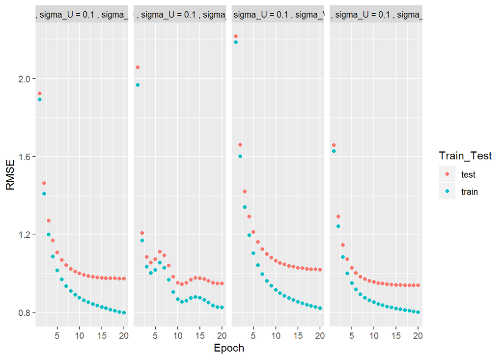

```r
cv.grap <- cv.return %>%
  filter(D %in% pre_ft_D,
         sigma_U %in% pre_ft_sigma_U,
         sigma_V %in% pre_ft_sigma_V,
         lrate == pre_ft_lrate) %>%
  mutate(param_set = paste("D =",D,", sigma_U =", sigma_U, ", sigma_V =", sigma_V)) %>%
  select(-c(D,sigma_V,sigma_U,lrate)) %>%
  pivot_longer(-c(param_set), names_to = "Train_Test", values_to = "RMSE") %>%
  separate(Train_Test, into = c("Train_Test", "Epoch"), sep = "_") %>%
  mutate(Epoch = as.integer(Epoch))


a <- unique(cv.grap$param_set)[1:4]
b <- unique(cv.grap$param_set)[5:8]

cv.grap %>%
  filter(param_set %in% a) %>%
  ggplot(aes(x = Epoch, y = RMSE, col = Train_Test)) + geom_point() + facet_grid(~param_set)
```

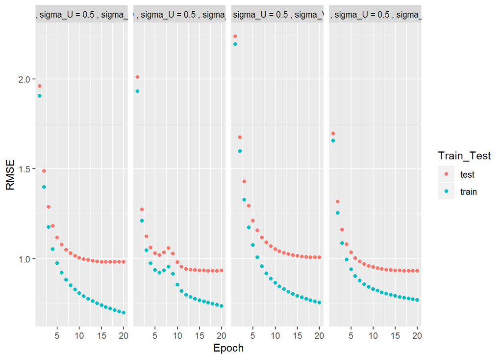

```
## Promising value for D is 10 and 5.
```

```
## Promising value for sigma_U is 0.1 and 0.5.
```

```
## Promising value for sigma_V is 1 and 0.5.
```

```
## We fix the learning rate to be 5e-04.
```

```r
cv.grap %>%
  filter(param_set %in% b) %>%
  ggplot(aes(x = Epoch, y = RMSE, col = Train_Test)) + geom_point() + facet_grid(~param_set)
```

### Step 3 Postprocessing

#### Step 3.2 P3:Postprocessing with kernel ridge regression

##### Step3.2.1 load the function for P3

```r
source("../lib/krr_cv.R")
```

##### Step 3.2.2 Tunning for A2+P3

```r
#tunes parameters
t_D <- c(5, 10)
t_sigma_V <- c(.1, .5)
t_sigma_U <- c(.5, 1)
t_lambda <- c(.5,1)
t_kernel <- c("Gaussian","Linear")

#build the data.frame to show all possible combination of parameters
par <- expand.grid(D = t_D, sigma_V = t_sigma_V, sigma_U = t_sigma_U,lambda = t_lambda,kernel = t_kernel)
```

Do cross validation

```r
cv_train_rmse <- c()
cv_test_rmse <- c()

for(i in dim(par)[1]){
  tmp_D <- par$D[i]
  tmp_sigma_V <- par$sigma_V[i]
  tmp_sigma_U <- par$sigma_U[i]
  tmp_lambda  <- par$lambda[i]
  tmp_kernel  <- par$kernel[i]

  ret <- cv_P3.function(data, data.train, K = 5,D = tmp_D, sigma_V = tmp_sigma_V, sigma_U = tmp_sigma_U, lambda = tmp_lambda, kernel = tmp_kernel)
  cat("--------------------------------------- No.",i,"Done --------------------------------------------", "\n")
  cv_train_rmse[i] <- ret$mean_train_rmse
  cv_test_rmse[i] <- ret$mean_test_rmse

}

cv_P3_train_rmse <- cv_train_rmse
cv_P3_test_rmse <- cv_test_rmse

rmse_P3<-par%>%
  mutate("train rmse" = cv_P3_train_rmse,
         "test rmse" = cv_P3_test_rmse)

save(rmse_P3, file = "../output/RMSE_A2_P3.RData")
```

Then we use these result to choose the best model for A2+P3 model based on the train RMSE and test RMSE we have.

```r
load("../output/RMSE_A2_P3.RData")

best_rmse_P3<-rmse_P3%>%
  arrange(`test rmse`,`train rmse`)
head(best_rmse_P3)
```

|  | D | sigma_V | sigma_U | lambda | kernel | train rmse | test rmse |
| --- | --- | --- | --- | --- | --- | --- | --- |
| 1 | 5 | 0.1 | 0.5 | 1.0 | Gaussian | 0.8987834 | 0.9157871 |
| 2 | 5 | 0.1 | 1.0 | 0.5 | Gaussian | 0.9087701 | 0.9187002 |
| 3 | 5 | 0.1 | 0.5 | 0.5 | Gaussian | 0.9106254 | 0.9216217 |
| 4 | 5 | 0.1 | 1.0 | 1.0 | Gaussian | 0.9102728 | 0.9250427 |
| 5 | 5 | 0.1 | 1.0 | 1.0 | Linear | 0.9106466 | 0.9274937 |
| 6 | 5 | 0.1 | 0.5 | 1.0 | Linear | 0.9099221 | 0.9288295 |

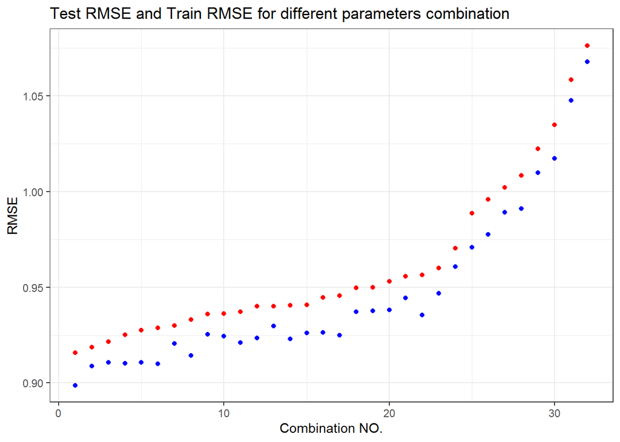

```r
g<-ggplot(best_rmse_P3)+
  geom_point(aes(x = 1:nrow(best_rmse_P3),y = `test rmse`),col = "red")+
  geom_point(aes(x = 1:nrow(best_rmse_P3),y = `train rmse`),col = "blue")+
  labs(x = "Combination NO.",
       y = "RMSE",
       title = "Test RMSE and Train RMSE for different parameters combination")+
  theme_bw()
g
```

##### Step 3.2.3 Output the model, the test RMSE and the rating matrix

```r
t0<-Sys.time()

output<-gradPMF(D = 5, data, data.train, data.test, sigma = .5,sigma_V = .1, sigma_U = .5, max.iter = 200, lrate = 0.0005, stopping.deriv = 0.01)
```

```
## =>=>=>=>=>=>=>=>=>=>epoch: 10    training RMSE: 3.141113     test RMSE: 3.179342
## =>=>=>=>=>=>=>=>=>=>epoch: 20    training RMSE: 2.070827     test RMSE: 2.16897
## =>=>=>=>=>=>=>=>=>=>epoch: 30    training RMSE: 1.609147     test RMSE: 1.748068
## =>=>=>=>=>=>=>=>=>=>epoch: 40    training RMSE: 1.365533     test RMSE: 1.53827
## =>=>=>=>=>=>=>=>=>=>epoch: 50    training RMSE: 1.214271     test RMSE: 1.416474
## =>=>=>=>=>=>=>=>=>=>epoch: 60    training RMSE: 1.111427     test RMSE: 1.339277
## =>=>=>=>=>=>=>=>=>=>epoch: 70    training RMSE: 1.037588     test RMSE: 1.287571
## =>=>=>=>=>=>=>=>=>=>epoch: 80    training RMSE: 0.9825142    test RMSE: 1.251554
## =>=>=>=>=>=>=>=>=>=>epoch: 90    training RMSE: 0.9402011    test RMSE: 1.225708
## =>=>=>=>=>=>=>=>=>=>epoch: 100   training RMSE: 0.9069001    test RMSE: 1.206734
## =>=>=>=>=>=>=>=>=>=>epoch: 110   training RMSE: 0.8801673    test RMSE: 1.192568
## =>=>=>=>=>=>=>=>=>=>epoch: 120   training RMSE: 0.8583507    test RMSE: 1.181865
## =>=>=>=>=>=>=>=>=>=>epoch: 130   training RMSE: 0.8402983    test RMSE: 1.173714
## =>=>=>=>=>=>=>=>=>=>epoch: 140   training RMSE: 0.825184     test RMSE: 1.167483
## =>=>=>=>=>=>=>=>=>=>epoch: 150   training RMSE: 0.8123999    test RMSE: 1.162719
## =>=>=>=>=>=>=>=>=>=>epoch: 160   training RMSE: 0.8014876    test RMSE: 1.159089
## =>=>=>=>=>=>=>=>=>=>epoch: 170   training RMSE: 0.7920942    test RMSE: 1.156349
## =>=>=>=>=>=>=>=>=>=>epoch: 180   training RMSE: 0.7839427    test RMSE: 1.154311
## =>=>=>=>=>=>=>=>=>=>epoch: 190   training RMSE: 0.7768133    test RMSE: 1.152833
## =>=>=>=>=>=>=>=>=>=>epoch: 200   training RMSE: 0.77053  test RMSE: 1.151805
```

```r
model_A2_p3<-P3(data.train, V = output$V, kernel = "Gaussian",lambda = 1)

t1<-Sys.time()

prediction_A2_P3<-predict.P3(data.new = data.test, model_A2_p3, V = output$V)

t2<-Sys.time()

test_RMSE_A2_P3<-sqrt(mean((data.test$rating-prediction_A2_P3)^2))

##Time for build the model is about 3.124177 mins
t1-t0
```

```
## Time difference of 3.039584 mins
```

```r
##Time for modeling and prediction is about 3.150982 mins
t2-t0
```

```
## Time difference of 3.06567 mins
```

```r
save(test_RMSE_A2_P3,file = "../output/test_RMSE_A2_P3.RData")
```

Calculate the user-movie prediction matrix.

```r
data.pred<-expand.grid(userId = c(1:610),movieId = sort(unique(data$movieId)))

t3<-Sys.time()
prediction<-predict.P3(data.new = data.pred, model_A2_p3, V = output$V)
t4<-Sys.time()

ratings_A2_P3<-cbind(data.pred,prediction)%>%
  pivot_wider(1:3,names_from = "movieId",values_from = "prediction")%>%
  select(-userId)

#Time for building the rating matrix is 5.124815 mins
t4-t3
```

```
## Time difference of 4.956768 mins
```

```r
#part of the rating matrix
ratings_A2_P3[1:5,1:5]
```

| 1 | 2 | 3 | 4 | 5 |
| --- | --- | --- | --- | --- |
| 4.669629 | 4.661545 | 4.5698866 | 4.163622 | 4.567758 |
| 3.967769 | 3.537307 | 3.4124804 | 2.842195 | 3.041565 |
| 1.328117 | 1.109184 | 0.9545336 | 2.147474 | 1.154621 |
| 3.238002 | 3.230077 | 3.5570914 | 3.329564 | 3.009627 |
| 3.822748 | 3.723681 | 3.4696679 | 2.888101 | 3.551717 |

```r
save(ratings_A2_P3,file = "../output/ratings_A2_P3.RData")
```